# Hepatitis A in Michigan from 1966 to 1987

April 25, 2018

## Introduction

- In this final project, we are going to study the Hepatitis A case in Michigan from 1966 to 1987.
- Hepatitis A is a worldwide public health problem. It is an infectious disease of the liver caused by the hepatitis A virus (HAV). Many cases have few or no symptoms, especially in the young. The time between infection and symptoms, in those who develop them, is between two and six weeks. When symptoms occur, they typically last eight weeks and may include nausea, vomiting, diarrhea, jaundice, fever, and abdominal pain. Around 10–15% of people experience a recurrence of symptoms during the six months after the initial infection. Acute liver failure may rarely occur, with this being more common in the elderly.[1] Thus, Hepatitis A is a good topic for SIR model we learned from class: people first get the virus by eating food or drinking water contaminated with infected feces, then some of them may get infection, because of the modern treatment, most people will recover from it and never get infection by this virus again.(They get anti-HAV in their body).
- We study the dynamics of hepatitis A virus (HAV) infection which can be controlled by vaccination as well as treatment. We modified the SIR model with SEICR model: E means exposed to HAV virus(infected but not yet infectious individuals (exposed)). C means chronic carriers Also lots of people get HAV vaccine immunity when they are born or when there is a outbreak aroud them. Besides, some people will get HAV for the second time because of losing the anti-HAV.

## Data

### Data source

- The data is from https://www.tycho.pitt.edu/ which is an open resource for infectious disease time series data. The original data contains the population who got HAV in every week in every state from 1966 to 1987. I extract the data for michigan and then change them to monthly data with the startcode.py.

```r
require(ggplot2)
sample <- read.csv("hep-a-mi.csv",header = TRUE)
head(sample)
```

```
##      State      time population
## 1 MICHIGAN  1/2/1966         84
## 2 MICHIGAN  1/9/1966         47
## 3 MICHIGAN 1/16/1966         71
## 4 MICHIGAN 1/23/1966         71
## 5 MICHIGAN 1/30/1966         50
## 6 MICHIGAN  2/6/1966         46
```

```r
hepa <- read.csv("hep-a-mi2.csv",header = TRUE)
head(hepa)
```

```
##   number population
## 1      1        273
## 2      2        241
## 3      3        325
## 4      4        240
## 5      5        194
## 6      6        160
```

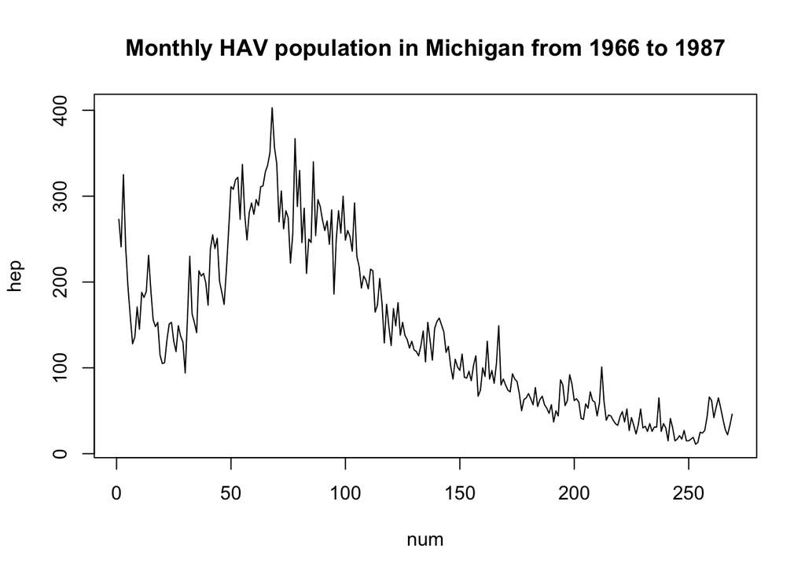

```r
hepa <- read.csv("hep-a-mi2.csv",header = TRUE)
hep <- hepa$population
num <- hepa$number
plot(hep~num,type='l',main="Monthly HAV population in Michigan from 1966 to 1987")
```

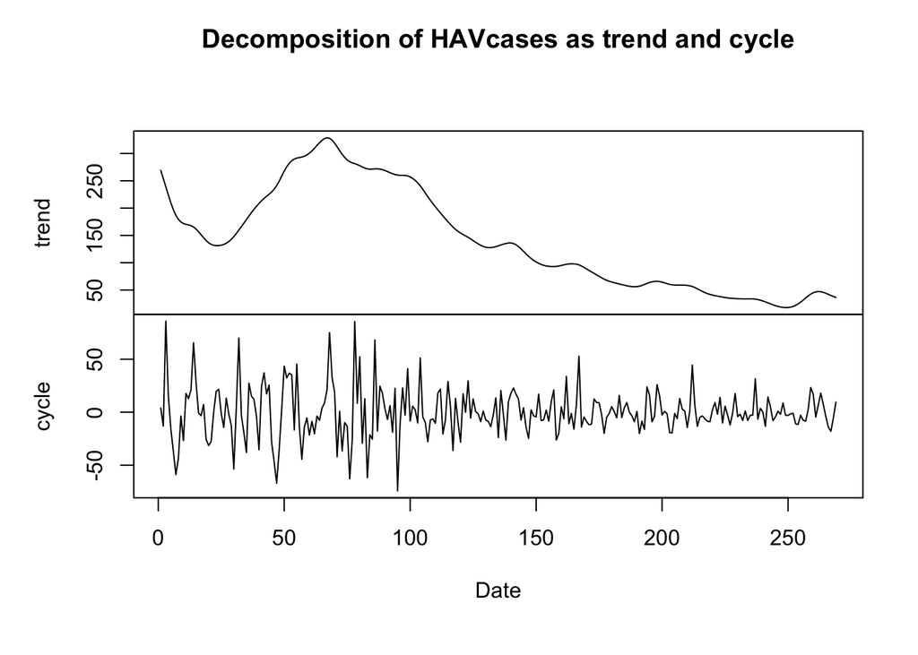

```r
library(mFilter)
hp=hpfilter(hep, freq=100,type="lambda",drift=F)
trend=ts(hp$trend)
cycle=ts(hp$cycle)
plot(ts.union(trend,cycle),type="l",xlab="Date",ylab="", main='Decomposition of HAVcases as trend and cycle')
```

- From the plot above, we can see there is a strong trend in the data, the peak may because of an outbreak of HAV which did not get controll around 1970. Then with the progress of modern treatment technology and sanitary condition, less and less people got HAV especially after about 1980.

## Pomp analysis

### SIR model

- Usually, an infectious disease can be represented by three stages, including susceptible, infectious and recovered. As the introduction in the first part(introduction), SIR is suitable for HAV. So we first build the model same as note 11[2], we have four states S,I,R,H.(The final population result from a process with probability ρ, which we can think of as the probability that an infection is severe enough to be noticed by the authorities. Since confined cases have, presumably, a much lower transmission rate, we need a variable H to track this.)
- The model is graphically represented as follows:

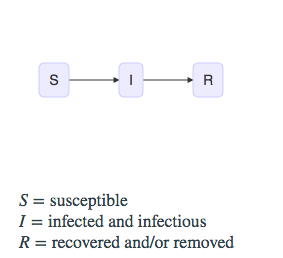

```r
hav <- read.csv("hep-a-mi2.csv")
hav<- subset(hav,select=c(number,population))
require(pomp)
```

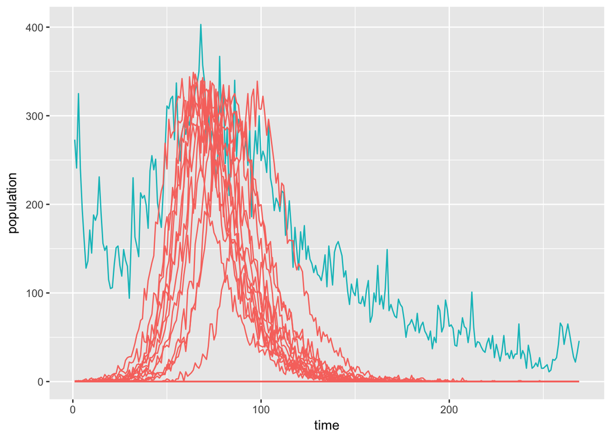

```r
sir_step <- Csnippet("
  double dN_SI = rbinom(S,1-exp(-Beta*I/N*dt));
  double dN_IR = rbinom(I,1-exp(-gamma*dt));
  S -= dN_SI;
  I += dN_SI - dN_IR;
  R += dN_IR;
  H += dN_IR;
")

sir_init <- Csnippet("
  S = N-1;
  I = 1;
  R = 0;
  H = 0;
")

pomp(hav,,time="number",t0=0,rprocess=euler.sim(sir_step,delta.t=1/4),initializer=sir_init,
     paramnames=c("Beta","gamma","N"),statenames=c("S","I","R","H")) -> sir
pomp(sir,zeronames="H") -> sir
dmeas <- Csnippet("lik = dbinom(population,H,rho,give_log);")
rmeas <- Csnippet("population = rbinom(H,rho);")
sir <- pomp(sir,rmeasure=rmeas,dmeasure=dmeas,statenames="H",paramnames="rho")
sims <- simulate(sir,params=c(Beta=0.25,gamma=0.1,rho=0.9,N=15000),nsim=20,as=TRUE,include=TRUE)
require(ggplot2)
ggplot(sims,mapping=aes(x=time,y=population,group=sim,color=sim=="data"),main='SIR simulation for HAV cases')+
  geom_line()+guides(color=FALSE)
```